# HU ML Problem Set 2

Aaron

September 22, 2016

### Instructions:

> Complete the following problems from the Kelleher book (Chapter 4) 2, 3, 4

### Calling helpers

```r
library(tidyverse)
library(readxl)
library(knitr)

pb_1 = read_excel("../data/homework2_data.xlsx", 1)
pb_2 = read_excel("../data/homework2_data.xlsx", 2)
pb_3 = read_excel("../data/homework2_data.xlsx", 3)
```

### Problem 2

A convicted criminal who reoffends after release is known as a $recidivist$. The table below lists a dataset that describes prisoners released on parole, and whether they reoffended within two years of release.

```r
pb_1 %>% kable()
```

| id | good_behavior | age_less_30 | drug_dependent | recidivist |
| --- | --- | --- | --- | --- |
| 1 | 0 | 1 | 0 | 1 |
| 2 | 0 | 0 | 0 | 0 |
| 3 | 0 | 1 | 0 | 1 |
| 4 | 1 | 0 | 0 | 0 |
| 5 | 1 | 0 | 1 | 1 |
| 6 | 1 | 0 | 0 | 0 |

This dataset lists six instances where prisoners were granted parole. Each of these instances are described in terms of three binary descriptive features **(`GOOD BEHAVIOR`, AGE < 30, DRUG DEPENDENT)** and a binary target feature, `RECIDIVIST`. The `GOOD BEHAVIOR` feature has a value of true if the prisoner had not committed any infringements during incarceration, the `AGE` < 30 has a value of true if the prisoner was under 30 years of age when granted parole, and the DRUG DEPENDENT feature is true if the prisoner had a drug addiction at the time of parole. The target feature, `RECIDIVIST`, has a true value if the prisoner was arrested within two years of being released; otherwise it has a value of false.

- Using this dataset, construct the decision tree that would be generated by the **ID3 algorithm**, using entropy-based information gain.
- What prediction will the decision tree generated in part (a) of this question return for the following query? `GOOD BEHAVIOR` = false, `AGE` < 30 = false, `DRUG DEPENDENT` = true
- What prediction will the decision tree generated in part (a) of this question return for the following query? `GOOD BEHAVIOR` = true, `AGE` < 30 = true, `DRUG DEPENDENT` = false

### Problem 3

The table below lists a sample of data from a census.

```r
pb_2 %>% kable()
```

| id | age | education | martial_arts | occupation | annual_income |
| --- | --- | --- | --- | --- | --- |
| 1 | 39 | bachelors | never married | transport | 25K-50K |
| 2 | 50 | bachelors | married | professional | 25K-50K |
| 3 | 18 | high school | never married | agriculture | <=25K |
| 4 | 28 | bachelors | married | professional | 25K-50K |
| 5 | 37 | high school | married | agriculture | 25K-50K |
| 6 | 24 | high school | never married | armed forces | <=25K |
| 7 | 52 | high school | divorced | transport | 25K-50K |
| 8 | 40 | doctorate | married | professional | >=50K |

There are four descriptive features and one target feature in this dataset:

- `AGE`, a continuous feature listing the age of the individual
- `EDUCATION`, a categorical feature listing the highest education award achieved by the individual (high school, bachelors, doctorate)
- `MARITAL STATUS` (never married, married, divorced)
- `OCCUPATION` (transport = works in the transportation industry; professional = doctors, lawyers, etc.; agriculture = works in the agricultural industry; armed forces = is a member of the armed forces)
- `ANNUAL INCOME`, the target feature with 3 levels (< 25K, 25K– 50K, > 50K)
- Calculate the **entropy** for this dataset.
- Calculate the **Gini index** for this dataset.
- When building a decision tree, the easiest way to handle a continuous feature is to define a threshold around which splits will be made. What would be the optimal threshold to split the continuous AGE feature (use information gain based on entropy as the feature selection measure)?
- Calculate **information gain** (based on entropy) for the `EDUCATION`, `MARITAL STATUS`, and `OCCUPATION` features.
- Calculate the **information gain ratio** (based on entropy) for `EDUCATION`, `MARITAL STATUS`, and `OCCUPATION` features.
- Calculate **information gain** using the **Gini index** for the `EDUCATION`, `MARITAL STATUS`, and `OCCUPATION` features.

### Problem 4

```r
pb_3 %>% kable()
```

| id | chest_pain | blood_pressure | heart_disease |
| --- | --- | --- | --- |
| 1 | 0 | high | 0 |
| 2 | 1 | low | 1 |
| 3 | 0 | low | 0 |
| 4 | 1 | high | 1 |
| 5 | 0 | high | 0 |

The diagram below shows a decision tree for the task of predicting heart disease. 33 The descriptive features in this domain describe whether the patient suffers from chest pain (`CHEST PAIN`) as well as the blood pressure of the patient (`BLOOD PRESSURE`). The binary target feature is `HEART DISEASE`. The table beside the diagram lists a pruning set from this domain.

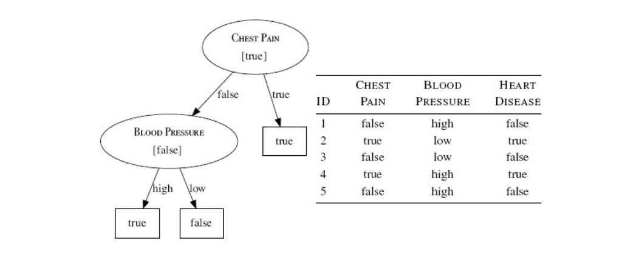

Using the pruning set, apply **reduced error pruning** to the decision tree. Assume that the algorithm is applied in a bottom-up, left-to-right fashion. For each iteration of the algorithm, indicate the subtrees considered as pruning candidates, explain why the algorithm chooses to prune or leave these subtrees in the tree, and illustrate the tree that results from each iteration.